# Сессия_1

*В этой сессии необходимо предобработать нашу выборку, что-бы при обучении результат прогноза выдовал высокую точность, для того, что-бы корректно обработать данные я воспользуюсь следующими пунктами:*

- *Разведочный анализ данных.*
- *Обработка пропущенных значений.*
- *Кодирование всех категориальных признаков.*
- *Нормализация данных.*
- *Преобразование значений.*

*Выполнения этих пунктов поспосопствует хорошему обучению.*

### Разведочный анализ

*Для понимания того, что это за данные, необходимо их изучить, вывести размер выборки, посмотреть на уникальные значения некоторых признаков и т.д.*

*Загружаю данные и все стандартные билиотеки машинного обучения:*

```python
import pandas as pd
import numpy as np
import matplotlib.pyplot as plt
import seaborn as sns
plt.rcParams ["figure.figsize"]=(6,4)
from sklearn.preprocessing import LabelEncoder
from sklearn.preprocessing import MinMaxScaler
from sklearn.model_selection import train_test_split
import warnings
warnings.filterwarnings('ignore')
```

```python
df=pd.read_csv("train.csv")
```

```python
df
```

|  | Id | MSSubClass | MSZoning | LotFrontage | LotArea | Street | Alley | LotShape | LandContour | Utilities | ... | PoolArea | PoolQC | Fence | MiscFeature | MiscVal | MoSold | YrSold | SaleType | SaleCondition | SalePrice |
| --- | --- | --- | --- | --- | --- | --- | --- | --- | --- | --- | --- | --- | --- | --- | --- | --- | --- | --- | --- | --- | --- |
| 0 | 1 | 60 | RL | 65.0 | 8450 | Pave | NaN | Reg | Lvl | AllPub | ... | 0 | NaN | NaN | NaN | 0 | 2 | 2008 | WD | Normal | 208500 |
| 1 | 2 | 20 | RL | 80.0 | 9600 | Pave | NaN | Reg | Lvl | AllPub | ... | 0 | NaN | NaN | NaN | 0 | 5 | 2007 | WD | Normal | 181500 |
| 2 | 3 | 60 | RL | 68.0 | 11250 | Pave | NaN | IR1 | Lvl | AllPub | ... | 0 | NaN | NaN | NaN | 0 | 9 | 2008 | WD | Normal | 223500 |
| 3 | 4 | 70 | RL | 60.0 | 9550 | Pave | NaN | IR1 | Lvl | AllPub | ... | 0 | NaN | NaN | NaN | 0 | 2 | 2006 | WD | Abnorml | 140000 |
| 4 | 5 | 60 | RL | 84.0 | 14260 | Pave | NaN | IR1 | Lvl | AllPub | ... | 0 | NaN | NaN | NaN | 0 | 12 | 2008 | WD | Normal | 250000 |
| ... | ... | ... | ... | ... | ... | ... | ... | ... | ... | ... | ... | ... | ... | ... | ... | ... | ... | ... | ... | ... | ... |
| 1455 | 1456 | 60 | RL | 62.0 | 7917 | Pave | NaN | Reg | Lvl | AllPub | ... | 0 | NaN | NaN | NaN | 0 | 8 | 2007 | WD | Normal | 175000 |
| 1456 | 1457 | 20 | RL | 85.0 | 13175 | Pave | NaN | Reg | Lvl | AllPub | ... | 0 | NaN | MnPrv | NaN | 0 | 2 | 2010 | WD | Normal | 210000 |
| 1457 | 1458 | 70 | RL | 66.0 | 9042 | Pave | NaN | Reg | Lvl | AllPub | ... | 0 | NaN | GdPrv | Shed | 2500 | 5 | 2010 | WD | Normal | 266500 |
| 1458 | 1459 | 20 | RL | 68.0 | 9717 | Pave | NaN | Reg | Lvl | AllPub | ... | 0 | NaN | NaN | NaN | 0 | 4 | 2010 | WD | Normal | 142125 |
| 1459 | 1460 | 20 | RL | 75.0 | 9937 | Pave | NaN | Reg | Lvl | AllPub | ... | 0 | NaN | NaN | NaN | 0 | 6 | 2008 | WD | Normal | 147500 |

1460 rows × 81 columns

*Узнаю размер данных:*

```python
df.shape
```

```
(1460, 81)
```

*Данные имеют 1460 объектов на 81 признака, это означает что наши данные большого размера и вних много ненужной информации.*

*Теперь посмотри,сколько уникальных значений имеет целевой признак SalePrice:*

```python
df['SalePrice'].nunique()
```

```
663
```

*Далее посмотрим на типы всех переменных в выборке:*

```python
for col in df.columns:
    missing=df[col].dtypes
    print('Признак:{}'.format(missing))
```

```
Признак:int64
Признак:int64
Признак:object
Признак:float64
Признак:int64
Признак:object
Признак:object
Признак:object
Признак:object
Признак:object
Признак:object
Признак:object
Признак:object
Признак:object
Признак:object
Признак:object
Признак:object
Признак:int64
Признак:int64
Признак:int64
Признак:int64
Признак:object
Признак:object
Признак:object
Признак:object
Признак:object
Признак:float64
Признак:object
Признак:object
Признак:object
Признак:object
Признак:object
Признак:object
Признак:object
Признак:int64
Признак:object
Признак:int64
Признак:int64
Признак:int64
Признак:object
```

[output cut: 26 more lines]

```
Признак:int64
Признак:int64
Признак:int64
Признак:int64
Признак:int64
Признак:int64
Признак:object
Признак:object
Признак:object
Признак:int64
Признак:int64
Признак:int64
Признак:object
Признак:object
Признак:int64
```

*Выведу статистическую таблицу для понимания из каких значений состоит выборка:*

```python
df.describe()
```

|  | Id | MSSubClass | LotFrontage | LotArea | OverallQual | OverallCond | YearBuilt | YearRemodAdd | MasVnrArea | BsmtFinSF1 | ... | WoodDeckSF | OpenPorchSF | EnclosedPorch | 3SsnPorch | ScreenPorch | PoolArea | MiscVal | MoSold | YrSold | SalePrice |
| --- | --- | --- | --- | --- | --- | --- | --- | --- | --- | --- | --- | --- | --- | --- | --- | --- | --- | --- | --- | --- | --- |
| count | 1460.000000 | 1460.000000 | 1201.000000 | 1460.000000 | 1460.000000 | 1460.000000 | 1460.000000 | 1460.000000 | 1452.000000 | 1460.000000 | ... | 1460.000000 | 1460.000000 | 1460.000000 | 1460.000000 | 1460.000000 | 1460.000000 | 1460.000000 | 1460.000000 | 1460.000000 | 1460.000000 |
| mean | 730.500000 | 56.897260 | 70.049958 | 10516.828082 | 6.099315 | 5.575342 | 1971.267808 | 1984.865753 | 103.685262 | 443.639726 | ... | 94.244521 | 46.660274 | 21.954110 | 3.409589 | 15.060959 | 2.758904 | 43.489041 | 6.321918 | 2007.815753 | 180921.195890 |
| std | 421.610009 | 42.300571 | 24.284752 | 9981.264932 | 1.382997 | 1.112799 | 30.202904 | 20.645407 | 181.066207 | 456.098091 | ... | 125.338794 | 66.256028 | 61.119149 | 29.317331 | 55.757415 | 40.177307 | 496.123024 | 2.703626 | 1.328095 | 79442.502883 |
| min | 1.000000 | 20.000000 | 21.000000 | 1300.000000 | 1.000000 | 1.000000 | 1872.000000 | 1950.000000 | 0.000000 | 0.000000 | ... | 0.000000 | 0.000000 | 0.000000 | 0.000000 | 0.000000 | 0.000000 | 0.000000 | 1.000000 | 2006.000000 | 34900.000000 |
| 25% | 365.750000 | 20.000000 | 59.000000 | 7553.500000 | 5.000000 | 5.000000 | 1954.000000 | 1967.000000 | 0.000000 | 0.000000 | ... | 0.000000 | 0.000000 | 0.000000 | 0.000000 | 0.000000 | 0.000000 | 0.000000 | 5.000000 | 2007.000000 | 129975.000000 |
| 50% | 730.500000 | 50.000000 | 69.000000 | 9478.500000 | 6.000000 | 5.000000 | 1973.000000 | 1994.000000 | 0.000000 | 383.500000 | ... | 0.000000 | 25.000000 | 0.000000 | 0.000000 | 0.000000 | 0.000000 | 0.000000 | 6.000000 | 2008.000000 | 163000.000000 |
| 75% | 1095.250000 | 70.000000 | 80.000000 | 11601.500000 | 7.000000 | 6.000000 | 2000.000000 | 2004.000000 | 166.000000 | 712.250000 | ... | 168.000000 | 68.000000 | 0.000000 | 0.000000 | 0.000000 | 0.000000 | 0.000000 | 8.000000 | 2009.000000 | 214000.000000 |
| max | 1460.000000 | 190.000000 | 313.000000 | 215245.000000 | 10.000000 | 9.000000 | 2010.000000 | 2010.000000 | 1600.000000 | 5644.000000 | ... | 857.000000 | 547.000000 | 552.000000 | 508.000000 | 480.000000 | 738.000000 | 15500.000000 | 12.000000 | 2010.000000 | 755000.000000 |

8 rows × 38 columns

### Обработка пропущенных значений

*Существует три способа обработки пропущенных значений количественных признаков, и два способа для категориальных признаков:*

**Для количественных признаков:**

- *Удаление значений или признаков с пропущенными значениями(используется если размер выборки большой, а пропущенных значений мало.)*
- *Замена пропущенных значений на статистические велечины(используется если значение отсутсвует по каким-то случайным ситуациям, считается самым стандартным способом.)*
- *Прогнозирование значений(приеняется если значения отсутствуют не случайно, и имеют взаимосвязь между переменными выбранами для вминения, иначе это может привести к неточной оценки.)*

**Для категориальных признаков:**

- *Замнена пропущенных значений на моду числа(хорошо работает, если очень много повторяющихся признаков.)*
- *Замнена пропущенных значений на новую категорию(если значение отсутствует случайно.)*

*Для того, что-бы определить каким методом воспльзоваться, нужно вывести процент пропущенных значений для каждого атрибута, если атрибут имеет больше 80 процентов, он считается неинформативным и его необходимо удалить:*

```python
for col in df.columns:
    missing=np.mean(df[col].isnull())
    missing_non=missing*100
    print('Признак:{}-пропущенные значения:{}%'.format(col, round(missing_non)))
    if missing_non>80:
        del df[col]
```

```
Признак:Id-пропущенные значения:0%
Признак:MSSubClass-пропущенные значения:0%
Признак:MSZoning-пропущенные значения:0%
Признак:LotFrontage-пропущенные значения:18%
Признак:LotArea-пропущенные значения:0%
Признак:Street-пропущенные значения:0%
Признак:Alley-пропущенные значения:94%
Признак:LotShape-пропущенные значения:0%
Признак:LandContour-пропущенные значения:0%
Признак:Utilities-пропущенные значения:0%
Признак:LotConfig-пропущенные значения:0%
Признак:LandSlope-пропущенные значения:0%
Признак:Neighborhood-пропущенные значения:0%
Признак:Condition1-пропущенные значения:0%
Признак:Condition2-пропущенные значения:0%
Признак:BldgType-пропущенные значения:0%
Признак:HouseStyle-пропущенные значения:0%
Признак:OverallQual-пропущенные значения:0%
Признак:OverallCond-пропущенные значения:0%
Признак:YearBuilt-пропущенные значения:0%
Признак:YearRemodAdd-пропущенные значения:0%
Признак:RoofStyle-пропущенные значения:0%
Признак:RoofMatl-пропущенные значения:0%
Признак:Exterior1st-пропущенные значения:0%
Признак:Exterior2nd-пропущенные значения:0%
Признак:MasVnrType-пропущенные значения:1%
Признак:MasVnrArea-пропущенные значения:1%
Признак:ExterQual-пропущенные значения:0%
Признак:ExterCond-пропущенные значения:0%
Признак:Foundation-пропущенные значения:0%
Признак:BsmtQual-пропущенные значения:3%
Признак:BsmtCond-пропущенные значения:3%
Признак:BsmtExposure-пропущенные значения:3%
Признак:BsmtFinType1-пропущенные значения:3%
Признак:BsmtFinSF1-пропущенные значения:0%
Признак:BsmtFinType2-пропущенные значения:3%
Признак:BsmtFinSF2-пропущенные значения:0%
Признак:BsmtUnfSF-пропущенные значения:0%
Признак:TotalBsmtSF-пропущенные значения:0%
Признак:Heating-пропущенные значения:0%
```

[output cut: 26 more lines]

```
Признак:WoodDeckSF-пропущенные значения:0%
Признак:OpenPorchSF-пропущенные значения:0%
Признак:EnclosedPorch-пропущенные значения:0%
Признак:3SsnPorch-пропущенные значения:0%
Признак:ScreenPorch-пропущенные значения:0%
Признак:PoolArea-пропущенные значения:0%
Признак:PoolQC-пропущенные значения:100%
Признак:Fence-пропущенные значения:81%
Признак:MiscFeature-пропущенные значения:96%
Признак:MiscVal-пропущенные значения:0%
Признак:MoSold-пропущенные значения:0%
Признак:YrSold-пропущенные значения:0%
Признак:SaleType-пропущенные значения:0%
Признак:SaleCondition-пропущенные значения:0%
Признак:SalePrice-пропущенные значения:0%
```

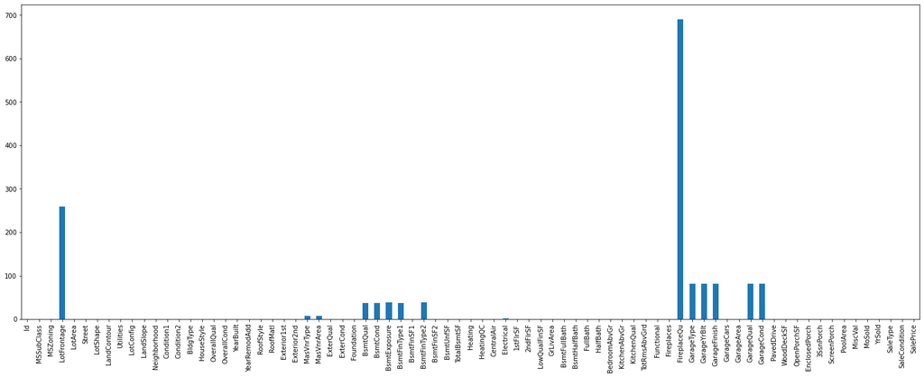

```python
plt.figure(figsize=(25,9))
df.isnull().sum().plot(kind='bar')
plt.show();
```

*Исходя из процента пропущенных значений и графика ,можно сделать вывод, что значений отсутствует не мало, и скорее всего отсутствие их случайно, так как данные связаны с недвижемостью и при заполнении выборки просто забыли внести некоторые значения.*

*Знаит стоит применить к количественным признакам - замену на медианное значение, а к категориальным логичным будет применить добовление новой категории:*

```python
numeric = df.select_dtypes(exclude=[np.number])
numeric_cols = numeric.columns.values

for col in numeric_cols:
    missing = df[col].isnull()
    num_missing = np.sum(missing)

    if num_missing > 0:
        print('Признак с пропущенными значениями: {}'.format(col))
        df[col]=df[col].fillna('Неизвестно')
```

```
Признак с пропущенными значениями: MasVnrType
Признак с пропущенными значениями: BsmtQual
Признак с пропущенными значениями: BsmtCond
Признак с пропущенными значениями: BsmtExposure
Признак с пропущенными значениями: BsmtFinType1
Признак с пропущенными значениями: BsmtFinType2
Признак с пропущенными значениями: Electrical
Признак с пропущенными значениями: FireplaceQu
Признак с пропущенными значениями: GarageType
Признак с пропущенными значениями: GarageFinish
Признак с пропущенными значениями: GarageQual
Признак с пропущенными значениями: GarageCond
```

```python
numeric = df.select_dtypes(include=[np.number])
numeric_cols = numeric.columns.values

for col in numeric_cols:
    missing = df[col].isnull()
    num_missing = np.sum(missing)

    if num_missing > 0:
        print('Признак с пропущенными значениями: {}'.format(col))
        med=df[col].median()
        df[col]=df[col].fillna(med)
```

```
Признак с пропущенными значениями: LotFrontage
Признак с пропущенными значениями: MasVnrArea
Признак с пропущенными значениями: GarageYrBlt
```

### Кодирование всех категориальных признаков

*Закодируем номинативные признаки, так как известно, что осуществляться обучение признака может тольско с числами:*

```python
labl=LabelEncoder()
nomic=df.select_dtypes(exclude=[np.number])
for col in df.columns:
    df[col]=labl.fit_transform(df[col])
```

### Преобразование значений.

```python
rew=len(df.index)
informat=[]
for col in df.columns:
    conts=df[col].value_counts()
    self=(conts/rew).iloc[0]
    if self>0.8:
        del df[col]
        print('{}-deleted'.format(col))
```

```
Street-deleted
LandContour-deleted
Utilities-deleted
LandSlope-deleted
Condition1-deleted
Condition2-deleted
BldgType-deleted
RoofMatl-deleted
ExterCond-deleted
BsmtCond-deleted
BsmtFinType2-deleted
BsmtFinSF2-deleted
Heating-deleted
CentralAir-deleted
Electrical-deleted
LowQualFinSF-deleted
BsmtHalfBath-deleted
KitchenAbvGr-deleted
Functional-deleted
GarageQual-deleted
GarageCond-deleted
PavedDrive-deleted
EnclosedPorch-deleted
3SsnPorch-deleted
ScreenPorch-deleted
PoolArea-deleted
MiscVal-deleted
SaleType-deleted
SaleCondition-deleted
```

```python
for col in df.columns:
    x=np.array(df['SalePrice'])
    y=np.array(df[col])
    coef=np.corrcoef(x,y)[0,1]
    if coef>0.2 and coef<0.9:
        print('{}-имеет сильную корреляцию:{}'.format(col,coef))
        del df[col]
```

```
LotFrontage-имеет сильную корреляцию:0.35956312253181894
LotArea-имеет сильную корреляцию:0.46558433663648263
HouseStyle-имеет сильную корреляцию:0.22520705531252358
OverallQual-имеет сильную корреляцию:0.816896103325575
YearBuilt-имеет сильную корреляцию:0.6178758454228398
YearRemodAdd-имеет сильную корреляцию:0.5793086350174973
MasVnrArea-имеет сильную корреляцию:0.4305036164491282
Foundation-имеет сильную корреляцию:0.4334602987411817
BsmtFinSF1-имеет сильную корреляцию:0.3500028065134111
TotalBsmtSF-имеет сильную корреляцию:0.6340170593555408
1stFlrSF-имеет сильную корреляцию:0.600353328592405
2ndFlrSF-имеет сильную корреляцию:0.3975561325076477
GrLivArea-имеет сильную корреляцию:0.736875536046757
BsmtFullBath-имеет сильную корреляцию:0.22907364354014212
FullBath-имеет сильную корреляцию:0.6182046675692005
HalfBath-имеет сильную корреляцию:0.32095409535622377
TotRmsAbvGrd-имеет сильную корреляцию:0.5259136304954676
Fireplaces-имеет сильную корреляцию:0.49610951917337226
GarageYrBlt-имеет сильную корреляцию:0.5292534994374909
GarageCars-имеет сильную корреляцию:0.6810074991567998
GarageArea-имеет сильную корреляцию:0.6636266135187237
WoodDeckSF-имеет сильную корреляцию:0.33979645238143025
OpenPorchSF-имеет сильную корреляцию:0.376009233322873
```

### Нормализация данных

```python
scaler=MinMaxScaler()
df_scal=scaler.fit_transform(df.drop("SalePrice", axis=1))
pd_scaler=pd.DataFrame(df_scal, columns=df.drop("SalePrice",axis=1).columns)
```

# Сессия_2

*В этой сессии необходимо выбрать признаки для дальнейшего обучения, это должно увеличить вероятность предсказания класса.Также необходимо выбрать алгоритм регрессии.*

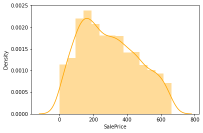

```python
sns.distplot(df['SalePrice'], color='orange');
```

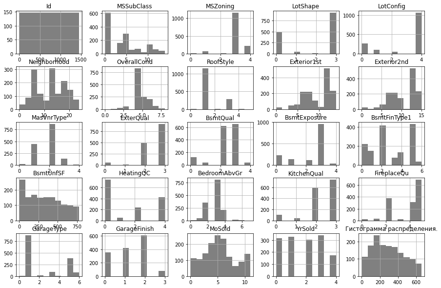

```python
df.hist(color='grey', figsize=(15,10))
plt.title('Гистограмма распределения.')
plt.show();
```

*Я предпочту использовать следующие алгоритмы регрессии: Лассо-так-как этот алгоритм может выполнять встроенный выбор признаков, а также сжатие параметров.Гребневая регрессия- позволяет получить все переменные, но с сокращенными параметрами.* ElasticNetCV- алгоритм стремиться объединить лучшее из гребневой регрессии и регрессии лассо.*

```python
from sklearn.linear_model import LassoCV
from sklearn.linear_model import RidgeCV
from sklearn.linear_model import ElasticNetCV
from sklearn.metrics import mean_squared_error
```

# Сессия_3

*Выполнив эту сессию, целевая переменная выборки будет уже обучена, по результатам обучения нужно будет выбрать лучшую модель:*

*Для того, что-бы обучение после предобработки было корректным, необходимо разделить нашу выборку на тестовую и тренировочную:*

```python
X=df_scal.copy()
Y=df['SalePrice']
X_train, X_test, Y_train, Y_test=train_test_split(X,Y, test_size=0.2, random_state=30)
```

*Обучение целевог признака на регрессии Лассо:*

```python
lasso = LassoCV()
```

```python
lasso.fit(X_train, Y_train)
```

```
LassoCV()
```

```python
y_pred=lasso.predict(X_test)
```

```python
lasso_predict=mean_squared_error(Y_test, y_pred)
```

*Применение к выборке гребневой регрессии:*

```python
greb =RidgeCV()
```

```python
greb.fit(X_train, Y_train)
```

```
RidgeCV(alphas=array([ 0.1,  1. , 10. ]))
```

```python
y_pred=greb.predict(X_test)
```

```python
greb_predict=mean_squared_error(Y_test, y_pred)
```

*Использование в качестве регрессии ElasticNetCV:*

```python
estet =ElasticNetCV()
```

```python
estet.fit(X_train, Y_train)
```

```
ElasticNetCV()
```

```python
y_pred=estet.predict(X_test)
```

```python
estet_predict=mean_squared_error(Y_test, y_pred)
```

[figure not shown]

```python
plt.style.use('fivethirtyeight')
plt.figure(figsize=(12, 10))
model_comparison = pd.DataFrame({'model': ['LassoCV', 'RidgeCV',
                                           'ElasticNetCV'],
                                 'mae': [lasso_predict, greb_predict,
                                         estet_predict]})
model_comparison.sort_values('mae', ascending = False).plot(x = 'model', y = 'mae', kind = 'barh',
                                                           color = 'black', edgecolor = 'black')
plt.ylabel(''); plt.yticks(size = 16); plt.xlabel('Mean_Squared_Error'); plt.xticks(size = 16)
plt.title('Model Comparison on Test MAE', size = 24)
plt.show();
```

*Все три алгоритма выявили хороший результат, но точность средний квадратной метрики показала, что лучший результат дала гребневая регрессия.*